# Chapter4: Latitude - Mass data

# Descriptive statistics

```r
MinMax <- function(x) paste0('[', min(x, na.rm = TRUE), ', ', max(x, na.rm = TRUE), ']')
Range <- function(x) max(x, na.rm = TRUE) - min(x, na.rm = TRUE)
datasummary(REGION*(LENGTH + MASS) + (LENGTH + MASS) ~  median + MinMax + Range + Histogram,
            data=growth3)
```

| REGION |  | median | MinMax | Range | Histogram |
| --- | --- | --- | --- | --- | --- |
| core | LENGTH | 31.47 | [15.15, 46.82] | 31.67 | ▁▃▆▇▄▁ |
|  | MASS | 1.09 | [0.0882, 3.106] | 3.02 | ▁▃▇▇▅▂▁ |
| leading | LENGTH | 31.35 | [16.16, 45.17] | 29.01 | ▁▃▆▇▅▂ |
|  | MASS | 1.07 | [0.138, 3.528] | 3.39 | ▁▄▇▅▃▁ |
|  | LENGTH | 31.45 | [15.15, 46.82] | 31.67 | ▁▃▆▇▄▁ |
|  | MASS | 1.08 | [0.0882, 3.528] | 3.44 | ▁▃▇▅▃▁ |

```r
datasummary(REGION * DEV_TEMP * (LENGTH + MASS) + (LENGTH + MASS) ~  median + MinMax + Range + Histogram,
            data=growth3)
```

| REGION | DEV_TEMP |  | median | MinMax | Range | Histogram |
| --- | --- | --- | --- | --- | --- | --- |
| core | 28.5 | LENGTH | 32.30 | [16.9, 45.09] | 28.19 | ▁▂▄▇▄▂ |
|  |  | MASS | 1.17 | [0.1226, 3.106] | 2.98 | ▂▅▇▅▂▁ |
|  | 30 | LENGTH | 31.29 | [16.15, 46.82] | 30.67 | ▁▃▇▇▂▁ |
|  |  | MASS | 1.07 | [0.1778, 2.7827] | 2.60 | ▁▂▇▇▅▃▁ |
|  | 31.5 | LENGTH | 30.42 | [15.15, 40.03] | 24.88 | ▁▂▄▆▇▅▃▁ |
|  |  | MASS | 1.02 | [0.0882, 2.79] | 2.70 | ▁▅▇▇▅▃▂▁▁▁ |
| leading | 28.5 | LENGTH | 31.95 | [16.16, 45.17] | 29.01 | ▁▂▆▇▅▂ |
|  |  | MASS | 1.09 | [0.138, 3.06] | 2.92 | ▁▃▇▆▅▃ |
|  | 30 | LENGTH | 32.35 | [16.43, 42.88] | 26.45 | ▁▁▄▆▇▄▁ |
|  |  | MASS | 1.16 | [0.3081, 2.6554] | 2.35 | ▁▄▇▇▇▅▂▁ |
|  | 31.5 | LENGTH | 30.01 | [17.98, 42.35] | 24.37 | ▁▃▇▅▄▁▁ |
|  |  | MASS | 0.97 | [0.1854, 3.528] | 3.34 | ▁▅▇▃▁ |
|  |  | LENGTH | 31.45 | [15.15, 46.82] | 31.67 | ▁▃▆▇▄▁ |
|  |  | MASS | 1.08 | [0.0882, 3.528] | 3.44 | ▁▃▇▅▃▁ |

note this also removes NA’s therefore the difference in data frames is 21 row:

- 1 datum point with MASS greater than 4
- 1 datum point with high value (removed via FULTONK being less than 0.01)
- 2 data points where the tank density was 2
- 9 data points with low values (removed via FULTONK being greater than 0.079)
- 8 NA’s removed
- **Total: 21**

Now Let’s look at out plots again

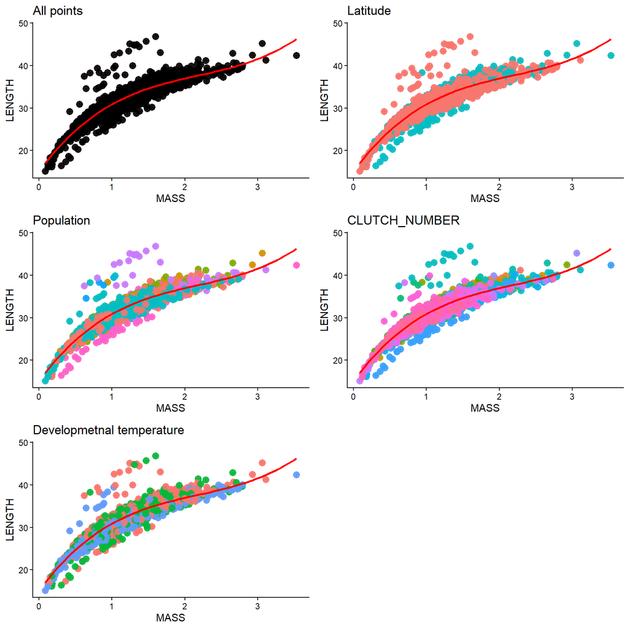